# 01_exploracao

```python
import pandas as pd
import numpy as np

import matplotlib.pyplot as plt
import seaborn as sns
```

```python
arquivo = "../data/raw/Municipio_Mensal_1T_2026.xlsx"
```

```python
excel = pd.ExcelFile(arquivo)
```

```python
excel.sheet_names
```

```
['Número de UC', 'Consumo MWh']
```

```python
df = pd.read_excel(arquivo, sheet_name="Consumo MWh")
```

```python
df.head()
```

|  | tipo | cod_muni | agência | núcleo | unidade | município | cod_classe | classe | 1994-01-01 00:00:00 | 1994-02-01 00:00:00 | ... | 2025-06-01 00:00:00 | 2025-07-01 00:00:00 | 2025-08-01 00:00:00 | 2025-09-01 00:00:00 | 2025-10-01 00:00:00 | 2025-11-01 00:00:00 | 2025-12-01 00:00:00 | 2026-01-01 00:00:00 | 2026-02-01 00:00:00 | 2026-03-01 00:00:00 |
| --- | --- | --- | --- | --- | --- | --- | --- | --- | --- | --- | --- | --- | --- | --- | --- | --- | --- | --- | --- | --- | --- |
| 0 | Cativo | 1101 | ARFLO | Núcleo Grande Capital | Florianópolis (sede) | Florianópolis | 1 | Residencial | 21357.147 | 20782.785 | ... | 52878.556648 | 60441.735810 | 54284.838228 | 58371.440918 | 53787.994558 | 53800.328053 | 56821.529842 | 87456.494352 | 86524.998202 | 83895.217345 |
| 1 | Cativo | 1101 | ARFLO | Núcleo Grande Capital | Florianópolis (sede) | Florianópolis | 2 | Industrial | 1698.383 | 1641.103 | ... | 2558.042630 | 2877.644839 | 2557.793542 | 2761.337071 | 2972.536314 | 2669.177959 | 2677.598859 | 3332.905398 | 3222.091413 | 3746.075399 |
| 2 | Cativo | 1101 | ARFLO | Núcleo Grande Capital | Florianópolis (sede) | Florianópolis | 3 | Comercial | 14766.175 | 13420.879 | ... | 24422.064633 | 22060.793725 | 23029.908608 | 23087.512572 | 22567.306346 | 22916.987372 | 24222.198117 | 30172.991984 | 32276.237126 | 35388.860964 |
| 3 | Cativo | 1101 | ARFLO | Núcleo Grande Capital | Florianópolis (sede) | Florianópolis | 4 | Rural | 25.908 | 23.863 | ... | 37.052000 | 43.193000 | 29.520000 | 37.073000 | 37.665 | 38.949800 | 43.244000 | 50.350000 | 33.971450 | 42.984200 |
| 4 | Cativo | 1101 | ARFLO | Núcleo Grande Capital | Florianópolis (sede) | Florianópolis | 5 | Poder Público | 6393.112 | 4903.650 | ... | 6667.282925 | 7209.118309 | 6673.288946 | 6409.265993 | 6528.080709 | 7015.699795 | 6543.715033 | 7558.026813 | 8207.902689 | 8857.708610 |

5 rows × 395 columns

```python
df.shape
```

```
(7716, 395)
```

```python
df.info()
```

```
<class 'pandas.DataFrame'>
RangeIndex: 7716 entries, 0 to 7715
Columns: 395 entries, tipo to 2026-03-01 00:00:00
dtypes: float64(386), int64(2), object(1), str(6)
memory usage: 23.3+ MB
```

```python
df.tail(5)
```

|  | tipo | cod_muni | agência | núcleo | unidade | município | cod_classe | classe | 1994-01-01 00:00:00 | 1994-02-01 00:00:00 | ... | 2025-06-01 00:00:00 | 2025-07-01 00:00:00 | 2025-08-01 00:00:00 | 2025-09-01 00:00:00 | 2025-10-01 00:00:00 | 2025-11-01 00:00:00 | 2025-12-01 00:00:00 | 2026-01-01 00:00:00 | 2026-02-01 00:00:00 | 2026-03-01 00:00:00 |
| --- | --- | --- | --- | --- | --- | --- | --- | --- | --- | --- | --- | --- | --- | --- | --- | --- | --- | --- | --- | --- | --- |
| 7711 | Livre | 17109 | ARITA | Núcleo Leste | Itajaí (sede) | Piçarras | 2 | Industrial | NaN | NaN | ... | NaN | NaN | NaN | NaN | NaN | NaN | NaN | NaN | NaN | 11.876050 |
| 7712 | Livre | 3101 | ARJOI | Núcleo Norte | Joinville (sede) | Joinville | 2 | Industrial | NaN | NaN | ... | NaN | NaN | NaN | NaN | NaN | NaN | NaN | NaN | NaN | 5.477670 |
| 7713 | Livre | 17108 | ARITA | Núcleo Leste | Itajaí (sede) | Barra Velha | 2 | Industrial | NaN | NaN | ... | NaN | NaN | NaN | NaN | NaN | NaN | NaN | NaN | NaN | 5.091900 |
| 7714 | Livre | 17110 | ARITA | Núcleo Leste | Itajaí (sede) | Penha | 2 | Industrial | NaN | NaN | ... | NaN | NaN | NaN | NaN | NaN | NaN | NaN | NaN | NaN | 9.759996 |
| 7715 | Livre | 7101 | ARJSL | Núcleo Norte | Jaraguá do Sul (unidade) | Jaraguá do Sul | 2 | Industrial | NaN | NaN | ... | NaN | NaN | NaN | NaN | NaN | NaN | NaN | NaN | NaN | 12.607623 |

5 rows × 395 columns

```python
df.columns
```

```
Index([             'tipo',          'cod_muni',           'agência',
                  'núcleo',           'unidade',         'município',
              'cod_classe',            'classe', 1994-01-01 00:00:00,
       1994-02-01 00:00:00,
       ...
       2025-06-01 00:00:00, 2025-07-01 00:00:00, 2025-08-01 00:00:00,
       2025-09-01 00:00:00, 2025-10-01 00:00:00, 2025-11-01 00:00:00,
       2025-12-01 00:00:00, 2026-01-01 00:00:00, 2026-02-01 00:00:00,
       2026-03-01 00:00:00],
      dtype='object', length=395)
```

```python
df["município"].nunique()
```

```
290
```

```python
df["município"].unique()
```

```
<StringArray>
[            'Florianópolis',                  'São José',
                   'Palhoça', 'Santo Amaro da Imperatriz',
              'Águas Mornas',                   'Biguaçu',
            'Antônio Carlos',    'Governador Celso Ramos',
                   'Tijucas',                 'Canelinha',
 ...
                'Sul Brasil',            'Lageado Grande',
              'Jardinópolis',                     'Irati',
                    'Ipuaçu',               'Águas Frias',
           'Santiago do Sul',                     'Jupiá',
                 'Bom Jesus',        'Bom Jesus do Oeste']
Length: 290, dtype: str
```

```python
df["classe"].value_counts()
```

```
classe
Industrial            2696
Comercial             2591
Revenda                477
Serviço Público        455
Rural                  326
Poder Público          301
Residencial            290
Iluminação Pública     290
Próprio                290
Name: count, dtype: int64
```

```python
df["tipo"].value_counts()
```

```
tipo
Livre     5106
Cativo    2610
Name: count, dtype: int64
```

```python
df["agência"].value_counts()
```

```
agência
ARBLU    984
ARFLO    952
ARITA    686
ARJOI    678
ARCHA    612
ARCRI    554
ARRSL    475
ARSMO    451
ARLAG    426
ARTUB    399
ARJOA    292
ARVID    288
ARJSL    266
ARCON    259
ARMAF    245
ARSBS    149
Name: count, dtype: int64
```

```python
df.groupby("município").size().sort_values(ascending=False)
```

```
município
Joinville                 486
Florianópolis             335
Blumenau                  274
Itajaí                    215
Brusque                   175
                         ...
Belmonte                    9
Tigrinhos                   9
São Pedro de Alcântara      9
Tunápolis                   9
Treze de Maio               9
Length: 290, dtype: int64
```

```python
df[df["município"] == "Joinville"][["município", "classe", "tipo"]]
```

|  | município | classe | tipo |
| --- | --- | --- | --- |
| 297 | Joinville | Residencial | Cativo |
| 298 | Joinville | Industrial | Cativo |
| 299 | Joinville | Comercial | Cativo |
| 300 | Joinville | Rural | Cativo |
| 301 | Joinville | Poder Público | Cativo |
| ... | ... | ... | ... |
| 7688 | Joinville | Comercial | Livre |
| 7695 | Joinville | Comercial | Livre |
| 7708 | Joinville | Comercial | Livre |
| 7709 | Joinville | Comercial | Livre |
| 7712 | Joinville | Industrial | Livre |

486 rows × 3 columns

```python
df[df["município"] == "Belmonte"][["município", "classe", "tipo"]]
```

|  | município | classe | tipo |
| --- | --- | --- | --- |
| 1458 | Belmonte | Residencial | Cativo |
| 1459 | Belmonte | Industrial | Cativo |
| 1460 | Belmonte | Comercial | Cativo |
| 1461 | Belmonte | Rural | Cativo |
| 1462 | Belmonte | Poder Público | Cativo |
| 1463 | Belmonte | Iluminação Pública | Cativo |
| 1464 | Belmonte | Serviço Público | Cativo |
| 1465 | Belmonte | Próprio | Cativo |
| 1466 | Belmonte | Revenda | Cativo |

```python
df[df["município"] == "Joinville"][["classe", "tipo"]].drop_duplicates()
```

|  | classe | tipo |
| --- | --- | --- |
| 297 | Residencial | Cativo |
| 298 | Industrial | Cativo |
| 299 | Comercial | Cativo |
| 300 | Rural | Cativo |
| 301 | Poder Público | Cativo |
| 302 | Iluminação Pública | Cativo |
| 303 | Serviço Público | Cativo |
| 304 | Próprio | Cativo |
| 305 | Revenda | Cativo |
| 2612 | Industrial | Livre |
| 2695 | Comercial | Livre |
| 4189 | Serviço Público | Livre |
| 7533 | Poder Público | Livre |

```python
df[df["município"] == "Belmonte"][["classe", "tipo"]].drop_duplicates()
```

|  | classe | tipo |
| --- | --- | --- |
| 1458 | Residencial | Cativo |
| 1459 | Industrial | Cativo |
| 1460 | Comercial | Cativo |
| 1461 | Rural | Cativo |
| 1462 | Poder Público | Cativo |
| 1463 | Iluminação Pública | Cativo |
| 1464 | Serviço Público | Cativo |
| 1465 | Próprio | Cativo |
| 1466 | Revenda | Cativo |

```python
df[df["município"] == "Joinville"]["unidade"].value_counts()
```

```
unidade
Joinville (sede)    486
Name: count, dtype: int64
```

```python
df[df["município"] == "Joinville"]["núcleo"].value_counts()
```

```
núcleo
Núcleo Norte    486
Name: count, dtype: int64
```

```python
df.columns.tolist()
```

```
['tipo',
 'cod_muni',
 'agência',
 'núcleo',
 'unidade',
 'município',
 'cod_classe',
 'classe',
 datetime.datetime(1994, 1, 1, 0, 0),
 datetime.datetime(1994, 2, 1, 0, 0),
 datetime.datetime(1994, 3, 1, 0, 0),
 datetime.datetime(1994, 4, 1, 0, 0),
 datetime.datetime(1994, 5, 1, 0, 0),
 datetime.datetime(1994, 6, 1, 0, 0),
 datetime.datetime(1994, 7, 1, 0, 0),
 datetime.datetime(1994, 8, 1, 0, 0),
 datetime.datetime(1994, 9, 1, 0, 0),
 datetime.datetime(1994, 10, 1, 0, 0),
 datetime.datetime(1994, 11, 1, 0, 0),
 datetime.datetime(1994, 12, 1, 0, 0),
 datetime.datetime(1995, 1, 1, 0, 0),
 datetime.datetime(1995, 2, 1, 0, 0),
 datetime.datetime(1995, 3, 1, 0, 0),
 datetime.datetime(1995, 4, 1, 0, 0),
 datetime.datetime(1995, 5, 1, 0, 0),
 datetime.datetime(1995, 6, 1, 0, 0),
 datetime.datetime(1995, 7, 1, 0, 0),
 datetime.datetime(1995, 8, 1, 0, 0),
 datetime.datetime(1995, 9, 1, 0, 0),
 datetime.datetime(1995, 10, 1, 0, 0),
 datetime.datetime(1995, 11, 1, 0, 0),
 datetime.datetime(1995, 12, 1, 0, 0),
 datetime.datetime(1996, 1, 1, 0, 0),
 datetime.datetime(1996, 2, 1, 0, 0),
 datetime.datetime(1996, 3, 1, 0, 0),
 datetime.datetime(1996, 4, 1, 0, 0),
 datetime.datetime(1996, 5, 1, 0, 0),
 datetime.datetime(1996, 6, 1, 0, 0),
 datetime.datetime(1996, 7, 1, 0, 0),
 datetime.datetime(1996, 8, 1, 0, 0),
```

[output cut: 340 more lines]

```
 datetime.datetime(2025, 1, 1, 0, 0),
 datetime.datetime(2025, 2, 1, 0, 0),
 datetime.datetime(2025, 3, 1, 0, 0),
 datetime.datetime(2025, 4, 1, 0, 0),
 datetime.datetime(2025, 5, 1, 0, 0),
 datetime.datetime(2025, 6, 1, 0, 0),
 datetime.datetime(2025, 7, 1, 0, 0),
 datetime.datetime(2025, 8, 1, 0, 0),
 datetime.datetime(2025, 9, 1, 0, 0),
 datetime.datetime(2025, 10, 1, 0, 0),
 datetime.datetime(2025, 11, 1, 0, 0),
 datetime.datetime(2025, 12, 1, 0, 0),
 datetime.datetime(2026, 1, 1, 0, 0),
 datetime.datetime(2026, 2, 1, 0, 0),
 datetime.datetime(2026, 3, 1, 0, 0)]
```

```python
df[df["município"] == "Joinville"].nunique()
```

```
tipo                     2
cod_muni                 1
agência                  1
núcleo                   1
unidade                  1
                      ...
2025-11-01 00:00:00    435
2025-12-01 00:00:00    439
2026-01-01 00:00:00    449
2026-02-01 00:00:00    455
2026-03-01 00:00:00    467
Length: 395, dtype: int64
```

```python
df[["tipo", "município", "classe"]].drop_duplicates()
```

|  | tipo | município | classe |
| --- | --- | --- | --- |
| 0 | Cativo | Florianópolis | Residencial |
| 1 | Cativo | Florianópolis | Industrial |
| 2 | Cativo | Florianópolis | Comercial |
| 3 | Cativo | Florianópolis | Rural |
| 4 | Cativo | Florianópolis | Poder Público |
| ... | ... | ... | ... |
| 7533 | Livre | Joinville | Poder Público |
| 7544 | Livre | Celso Ramos | Industrial |
| 7569 | Livre | Correia Pinto | Serviço Público |
| 7644 | Livre | Piratuba | Serviço Público |
| 7684 | Livre | Imaruí | Industrial |

3086 rows × 3 columns

```python
df[["tipo", "município", "classe", "agência"]].drop_duplicates()
```

|  | tipo | município | classe | agência |
| --- | --- | --- | --- | --- |
| 0 | Cativo | Florianópolis | Residencial | ARFLO |
| 1 | Cativo | Florianópolis | Industrial | ARFLO |
| 2 | Cativo | Florianópolis | Comercial | ARFLO |
| 3 | Cativo | Florianópolis | Rural | ARFLO |
| 4 | Cativo | Florianópolis | Poder Público | ARFLO |
| ... | ... | ... | ... | ... |
| 7533 | Livre | Joinville | Poder Público | ARJOI |
| 7544 | Livre | Celso Ramos | Industrial | ARLAG |
| 7569 | Livre | Correia Pinto | Serviço Público | ARLAG |
| 7644 | Livre | Piratuba | Serviço Público | ARJOA |
| 7684 | Livre | Imaruí | Industrial | ARTUB |

3086 rows × 4 columns

```python
df[["tipo", "município", "classe", "agência", "núcleo"]].drop_duplicates()
```

|  | tipo | município | classe | agência | núcleo |
| --- | --- | --- | --- | --- | --- |
| 0 | Cativo | Florianópolis | Residencial | ARFLO | Núcleo Grande Capital |
| 1 | Cativo | Florianópolis | Industrial | ARFLO | Núcleo Grande Capital |
| 2 | Cativo | Florianópolis | Comercial | ARFLO | Núcleo Grande Capital |
| 3 | Cativo | Florianópolis | Rural | ARFLO | Núcleo Grande Capital |
| 4 | Cativo | Florianópolis | Poder Público | ARFLO | Núcleo Grande Capital |
| ... | ... | ... | ... | ... | ... |
| 7533 | Livre | Joinville | Poder Público | ARJOI | Núcleo Norte |
| 7544 | Livre | Celso Ramos | Industrial | ARLAG | Núcleo Planalto |
| 7569 | Livre | Correia Pinto | Serviço Público | ARLAG | Núcleo Planalto |
| 7644 | Livre | Piratuba | Serviço Público | ARJOA | Núcleo Meio Oeste |
| 7684 | Livre | Imaruí | Industrial | ARTUB | Núcleo Sul |

3086 rows × 5 columns

```python
df.groupby(["tipo", "município", "classe"]).size().sort_values(ascending=False)
```

```
tipo    município      classe
Livre   Florianópolis  Comercial             278
        Joinville      Industrial            230
                       Comercial             227
        Blumenau       Comercial             143
        São José       Comercial             136
                                            ...
Cativo  Agrolândia     Rural                   1
                       Serviço Público         1
        Agronômica     Comercial               1
                       Iluminação Pública      1
        Taió           Industrial              1
Length: 3086, dtype: int64
```

```python
df[df["município"] == "Florianópolis"]["unidade"].unique()
```

```
<StringArray>
['Florianópolis (sede)']
Length: 1, dtype: str
```

```python
df[df["município"] == "Florianópolis"]["unidade"].nunique()
```

```
1
```

```python
df[df["município"] == "Florianópolis"]["agência"].unique()
```

```
<StringArray>
['ARFLO']
Length: 1, dtype: str
```

```python
for coluna in df.columns:
    print(coluna)
```

```
tipo
cod_muni
agência
núcleo
unidade
município
cod_classe
classe
1994-01-01 00:00:00
1994-02-01 00:00:00
1994-03-01 00:00:00
1994-04-01 00:00:00
1994-05-01 00:00:00
1994-06-01 00:00:00
1994-07-01 00:00:00
1994-08-01 00:00:00
1994-09-01 00:00:00
1994-10-01 00:00:00
1994-11-01 00:00:00
1994-12-01 00:00:00
1995-01-01 00:00:00
1995-02-01 00:00:00
1995-03-01 00:00:00
1995-04-01 00:00:00
1995-05-01 00:00:00
1995-06-01 00:00:00
1995-07-01 00:00:00
1995-08-01 00:00:00
1995-09-01 00:00:00
1995-10-01 00:00:00
1995-11-01 00:00:00
1995-12-01 00:00:00
1996-01-01 00:00:00
1996-02-01 00:00:00
1996-03-01 00:00:00
1996-04-01 00:00:00
1996-05-01 00:00:00
1996-06-01 00:00:00
1996-07-01 00:00:00
1996-08-01 00:00:00
```

[output cut: 340 more lines]

```
2025-01-01 00:00:00
2025-02-01 00:00:00
2025-03-01 00:00:00
2025-04-01 00:00:00
2025-05-01 00:00:00
2025-06-01 00:00:00
2025-07-01 00:00:00
2025-08-01 00:00:00
2025-09-01 00:00:00
2025-10-01 00:00:00
2025-11-01 00:00:00
2025-12-01 00:00:00
2026-01-01 00:00:00
2026-02-01 00:00:00
2026-03-01 00:00:00
```

```python
id_vars = [
    "tipo",
    "cod_muni",
    "agência",
    "núcleo",
    "unidade",
    "município",
    "cod_classe",
    "classe",
]
```

```python
df_long = df.melt(id_vars=id_vars, var_name="data", value_name="consumo_mwh")
```

```python
df_long.head()
```

|  | tipo | cod_muni | agência | núcleo | unidade | município | cod_classe | classe | data | consumo_mwh |
| --- | --- | --- | --- | --- | --- | --- | --- | --- | --- | --- |
| 0 | Cativo | 1101 | ARFLO | Núcleo Grande Capital | Florianópolis (sede) | Florianópolis | 1 | Residencial | 1994-01-01 00:00:00 | 21357.147 |
| 1 | Cativo | 1101 | ARFLO | Núcleo Grande Capital | Florianópolis (sede) | Florianópolis | 2 | Industrial | 1994-01-01 00:00:00 | 1698.383 |
| 2 | Cativo | 1101 | ARFLO | Núcleo Grande Capital | Florianópolis (sede) | Florianópolis | 3 | Comercial | 1994-01-01 00:00:00 | 14766.175 |
| 3 | Cativo | 1101 | ARFLO | Núcleo Grande Capital | Florianópolis (sede) | Florianópolis | 4 | Rural | 1994-01-01 00:00:00 | 25.908 |
| 4 | Cativo | 1101 | ARFLO | Núcleo Grande Capital | Florianópolis (sede) | Florianópolis | 5 | Poder Público | 1994-01-01 00:00:00 | 6393.112 |

# Pergunta de Pesquisa 1

## Como o consumo de energia elétrica está distribuído entre os municípios de Santa Catarina?

### Motivação

Esta é a primeira pergunta central definida no README do projeto.

```python
df_long.head()
```

|  | tipo | cod_muni | agência | núcleo | unidade | município | cod_classe | classe | data | consumo_mwh |
| --- | --- | --- | --- | --- | --- | --- | --- | --- | --- | --- |
| 0 | Cativo | 1101 | ARFLO | Núcleo Grande Capital | Florianópolis (sede) | Florianópolis | 1 | Residencial | 1994-01-01 00:00:00 | 21357.147 |
| 1 | Cativo | 1101 | ARFLO | Núcleo Grande Capital | Florianópolis (sede) | Florianópolis | 2 | Industrial | 1994-01-01 00:00:00 | 1698.383 |
| 2 | Cativo | 1101 | ARFLO | Núcleo Grande Capital | Florianópolis (sede) | Florianópolis | 3 | Comercial | 1994-01-01 00:00:00 | 14766.175 |
| 3 | Cativo | 1101 | ARFLO | Núcleo Grande Capital | Florianópolis (sede) | Florianópolis | 4 | Rural | 1994-01-01 00:00:00 | 25.908 |
| 4 | Cativo | 1101 | ARFLO | Núcleo Grande Capital | Florianópolis (sede) | Florianópolis | 5 | Poder Público | 1994-01-01 00:00:00 | 6393.112 |

```python
df_long["consumo_mwh"].dtype
```

```
dtype('O')
```

```python
df_long["consumo_mwh"].sample(20)
```

```
2190535          NaN
1635173          NaN
160322           NaN
2066474          NaN
2138273       70.316
1556666          NaN
1072999        0.192
1021805          0.0
1983775        0.366
486632        10.191
1275001        0.368
931777           NaN
154232           NaN
1313649      544.802
2864989    23.156877
867569           0.0
1010515          NaN
2943872     98.59066
2954585     73.97064
2676273          NaN
Name: consumo_mwh, dtype: object
```

```python
df_long["consumo_mwh"].apply(type).value_counts()
```

```
consumo_mwh
<class 'float'>    2985404
<class 'int'>          687
<class 'str'>            1
Name: count, dtype: int64
```

```python
df_long.loc[
    df_long["consumo_mwh"].apply(lambda x: isinstance(x, str)),
    ["município", "classe", "tipo", "data", "consumo_mwh"],
]
```

|  | município | classe | tipo | data | consumo_mwh |
| --- | --- | --- | --- | --- | --- |
| 2941381 | Marmeleiro | Industrial | Cativo | 2025-10-01 00:00:00 | cccccc |

```python
df_long.loc[2941375:2941385]
```

|  | tipo | cod_muni | agência | núcleo | unidade | município | cod_classe | classe | data | consumo_mwh |
| --- | --- | --- | --- | --- | --- | --- | --- | --- | --- | --- |
| 2941375 | Cativo | 11139 | ARSMO | Núcleo Oeste | São Miguel do Oeste (unidade) | Cunhataí | 5 | Poder Público | 2025-10-01 00:00:00 | 1.675 |
| 2941376 | Cativo | 11139 | ARSMO | Núcleo Oeste | São Miguel do Oeste (unidade) | Cunhataí | 6 | Iluminação Pública | 2025-10-01 00:00:00 | 0.058362 |
| 2941377 | Cativo | 11139 | ARSMO | Núcleo Oeste | São Miguel do Oeste (unidade) | Cunhataí | 7 | Serviço Público | 2025-10-01 00:00:00 | 5.113 |
| 2941378 | Cativo | 11139 | ARSMO | Núcleo Oeste | São Miguel do Oeste (unidade) | Cunhataí | 8 | Próprio | 2025-10-01 00:00:00 | 0 |
| 2941379 | Cativo | 11139 | ARSMO | Núcleo Oeste | São Miguel do Oeste (unidade) | Cunhataí | 9 | Revenda | 2025-10-01 00:00:00 | 0 |
| 2941380 | Cativo | 11141 | ARSMO | Núcleo Oeste | São Miguel do Oeste (unidade) | Marmeleiro | 1 | Residencial | 2025-10-01 00:00:00 | 1.154 |
| 2941381 | Cativo | 11141 | ARSMO | Núcleo Oeste | São Miguel do Oeste (unidade) | Marmeleiro | 2 | Industrial | 2025-10-01 00:00:00 | cccccc |
| 2941382 | Cativo | 11141 | ARSMO | Núcleo Oeste | São Miguel do Oeste (unidade) | Marmeleiro | 3 | Comercial | 2025-10-01 00:00:00 | 6.543845 |
| 2941383 | Cativo | 11141 | ARSMO | Núcleo Oeste | São Miguel do Oeste (unidade) | Marmeleiro | 4 | Rural | 2025-10-01 00:00:00 | 3.246 |
| 2941384 | Cativo | 11141 | ARSMO | Núcleo Oeste | São Miguel do Oeste (unidade) | Marmeleiro | 5 | Poder Público | 2025-10-01 00:00:00 | NaN |
| 2941385 | Cativo | 11141 | ARSMO | Núcleo Oeste | São Miguel do Oeste (unidade) | Marmeleiro | 6 | Iluminação Pública | 2025-10-01 00:00:00 | NaN |

### Tratamento da coluna `consumo_mwh`

```python
df_long["consumo_mwh"] = pd.to_numeric(df_long["consumo_mwh"], errors="coerce")
```

```python
df_long["consumo_mwh"].dtype
```

```
dtype('float64')
```

```python
df_long["consumo_mwh"].isna().sum()
```

```
np.int64(1248009)
```

```python
consumo_municipio = (
    df_long.groupby("município")["consumo_mwh"].sum().sort_values(ascending=False)
)

consumo_municipio.head(10)
```

```
município
Joinville         7.366386e+07
Florianópolis     3.449381e+07
Blumenau          3.335744e+07
Jaraguá do Sul    1.923137e+07
Chapecó           1.811047e+07
Itajaí            1.790081e+07
Brusque           1.596992e+07
Criciúma          1.564726e+07
São José          1.343145e+07
Caçador           1.078823e+07
Name: consumo_mwh, dtype: float64
```

```python
consumo_municipio.head(20)
```

```
município
Joinville             7.366386e+07
Florianópolis         3.449381e+07
Blumenau              3.335744e+07
Jaraguá do Sul        1.923137e+07
Chapecó               1.811047e+07
Itajaí                1.790081e+07
Brusque               1.596992e+07
Criciúma              1.564726e+07
São José              1.343145e+07
Caçador               1.078823e+07
Lages                 1.021806e+07
Balneário Camboriú    9.805522e+06
Tubarão               9.134962e+06
Concórdia             8.620788e+06
Três Barras           8.102760e+06
Palhoça               8.085546e+06
São Bento do Sul      7.761424e+06
Braço do Norte        7.630469e+06
Indaial               7.590013e+06
Videira               7.207628e+06
Name: consumo_mwh, dtype: float64
```

```python
consumo_municipio.describe()
```

```
count    2.900000e+02
mean     2.120089e+06
std      5.805621e+06
min      0.000000e+00
25%      1.922392e+05
50%      4.777811e+05
75%      1.609435e+06
max      7.366386e+07
Name: consumo_mwh, dtype: float64
```

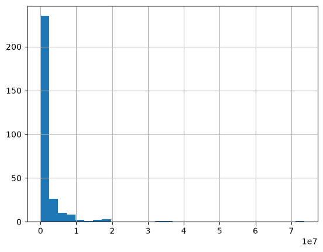

```python
consumo_municipio.hist(bins=30)
```

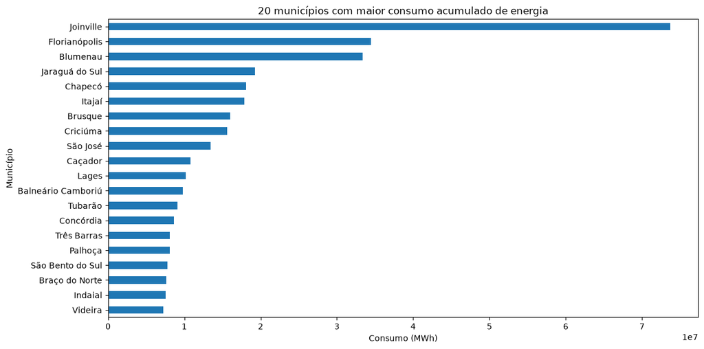

```python
import matplotlib.pyplot as plt

top20 = consumo_municipio.head(20)

plt.figure(figsize=(12, 6))

top20.sort_values().plot(kind="barh")

plt.title("20 municípios com maior consumo acumulado de energia")
plt.xlabel("Consumo (MWh)")
plt.ylabel("Município")

plt.tight_layout()
plt.show()
```

## Primeiras observações

O ranking mostra que poucos municípios concentram grande parte do consumo de energia elétrica em Santa Catarina.

Joinville apresenta o maior consumo acumulado da série histórica, seguido por Florianópolis e Blumenau. Também aparecem entre os primeiros municípios reconhecidos por sua atividade industrial, portuária ou tecnológica.

Esses resultados sugerem uma concentração do consumo em polos econômicos do estado, hipótese que será aprofundada nas próximas análises.

## Investigação 1.1 — Qual classe de consumo concentra a maior demanda de energia?

```python
consumo_classe = (
    df_long.groupby("classe")["consumo_mwh"].sum().sort_values(ascending=False)
)

consumo_classe
```

```
classe
Industrial            2.608849e+08
Residencial           1.448805e+08
Comercial             9.533280e+07
Rural                 4.035880e+07
Revenda               3.716981e+07
Iluminação Pública    1.582907e+07
Poder Público         1.075193e+07
Serviço Público       9.190330e+06
Próprio               4.276953e+05
Name: consumo_mwh, dtype: float64
```

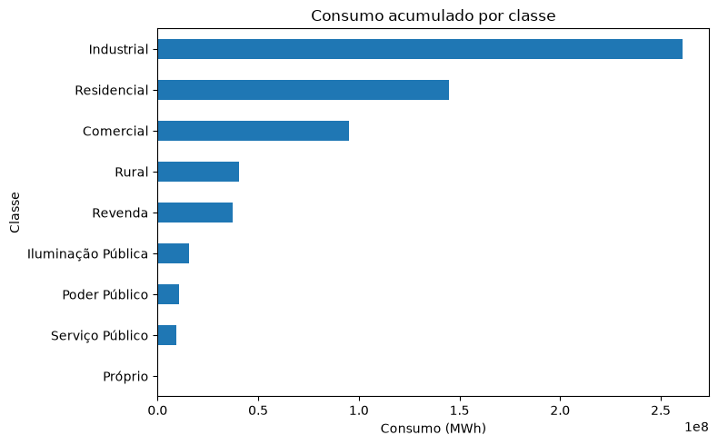

```python
plt.figure(figsize=(8, 5))

consumo_classe.sort_values().plot(kind="barh")

plt.title("Consumo acumulado por classe")
plt.xlabel("Consumo (MWh)")
plt.ylabel("Classe")

plt.tight_layout()
plt.show()
```

## Interpretação

A análise por classe mostra que o consumo industrial representa a maior parcela da demanda de energia elétrica em Santa Catarina.

Em seguida aparecem as classes Residencial e Comercial.

Esse resultado é consistente com o perfil econômico do estado, caracterizado por uma forte presença do setor industrial, especialmente em municípios como Joinville, Blumenau, Jaraguá do Sul, Brusque e Chapecó.

Esses resultados reforçam a hipótese de que a atividade econômica exerce papel relevante na concentração do consumo de energia observada entre os municípios.

## Investigação 1.2 — Como o consumo está distribuído entre os mercados Cativo e Livre?

```python
consumo_tipo = df_long.groupby("tipo")["consumo_mwh"].sum().sort_values(ascending=False)

consumo_tipo
```

```
tipo
Cativo    4.644911e+08
Livre     1.503347e+08
Name: consumo_mwh, dtype: float64
```

## Interpretação

O consumo acumulado mostra que o mercado Cativo representa a maior parcela da demanda de energia elétrica em Santa Catarina ao longo da série histórica analisada.

O mercado Livre, embora menor em volume total, também possui participação relevante, indicando a presença de consumidores de maior porte que negociam energia diretamente no Ambiente de Contratação Livre (ACL).

Nas próximas etapas será investigado se essa participação varia entre os municípios e entre as diferentes classes de consumo.

```python
consumo_municipio_tipo = (
    df_long.groupby(["município", "tipo"])["consumo_mwh"].sum().unstack(fill_value=0)
)

consumo_municipio_tipo.head()
```

| tipo município | Cativo | Livre |
| --- | --- | --- |
| Abdon Batista | 113495.595016 | 0.000000 |
| Abelardo Luz | 745976.084048 | 195923.910464 |
| Agrolândia | 637144.142624 | 153758.814365 |
| Agronômica | 277498.079737 | 2823.124685 |
| Alfredo Wagner | 382387.326205 | 65.982068 |

```python
consumo_municipio_tipo["Livre"].sort_values(ascending=False).head(20)
```

```
município
Joinville               2.924179e+07
Jaraguá do Sul          6.978691e+06
Blumenau                6.817877e+06
Três Barras             5.335347e+06
Caçador                 4.944895e+06
Chapecó                 4.549164e+06
Criciúma                3.899852e+06
Correia Pinto           3.553224e+06
Xanxerê                 3.499012e+06
São Francisco do Sul    3.145100e+06
Brusque                 3.113742e+06
Concórdia               3.096836e+06
Itajaí                  2.816890e+06
Indaial                 2.636306e+06
Videira                 2.322904e+06
Otacílio Costa          2.196885e+06
Fraiburgo               2.023871e+06
Lages                   2.022447e+06
Florianópolis           1.968171e+06
São Bento do Sul        1.925754e+06
Name: Livre, dtype: float64
```

```python
consumo_municipio_tipo["Cativo"].sort_values(ascending=False).head(20)
```

```
município
Joinville             4.442207e+07
Florianópolis         3.252564e+07
Blumenau              2.653956e+07
Itajaí                1.508392e+07
Chapecó               1.356130e+07
Brusque               1.285618e+07
Jaraguá do Sul        1.225268e+07
São José              1.216045e+07
Criciúma              1.174741e+07
Balneário Camboriú    9.577033e+06
Lages                 8.195618e+06
Tubarão               7.747910e+06
Palhoça               7.622191e+06
Braço do Norte        6.408046e+06
Forquilhinha          6.365230e+06
Caçador               5.843336e+06
São Bento do Sul      5.835670e+06
Concórdia             5.523952e+06
Gaspar                5.098795e+06
Indaial               4.953707e+06
Name: Cativo, dtype: float64
```

```python
participacao = consumo_municipio_tipo.copy()

participacao["% Livre"] = (
    participacao["Livre"] / (participacao["Livre"] + participacao["Cativo"])
) * 100

participacao.sort_values("% Livre", ascending=False).head(20)
```

| tipo município | Cativo | Livre | % Livre |
| --- | --- | --- | --- |
| Vidal Ramos | 3.038295e+05 | 1.211016e+06 | 79.943200 |
| Correia Pinto | 1.558044e+06 | 3.553224e+06 | 69.517465 |
| Três Barras | 2.767413e+06 | 5.335347e+06 | 65.846046 |
| Xanxerê | 2.200214e+06 | 3.499012e+06 | 61.394515 |
| Vargem Bonita | 6.934126e+05 | 9.313536e+05 | 57.322315 |
| Otacílio Costa | 1.747591e+06 | 2.196885e+06 | 55.695234 |
| Botuverá | 9.072686e+05 | 1.102628e+06 | 54.859940 |
| Treze Tílias | 7.675246e+05 | 7.242034e+05 | 48.547952 |
| Ipuaçu | 1.950542e+05 | 1.710322e+05 | 46.719073 |
| Caçador | 5.843336e+06 | 4.944895e+06 | 45.836009 |
| São Francisco do Sul | 3.795879e+06 | 3.145100e+06 | 45.312047 |
| Curitibanos | 2.048664e+06 | 1.587282e+06 | 43.655264 |
| Araquari | 2.091911e+06 | 1.613718e+06 | 43.547740 |
| Fraiburgo | 2.664936e+06 | 2.023871e+06 | 43.163877 |
| Capinzal | 1.918642e+06 | 1.432493e+06 | 42.746505 |
| Sangão | 1.395957e+06 | 1.019587e+06 | 42.209418 |
| Itapiranga | 1.580774e+06 | 1.108100e+06 | 41.210551 |
| Guaramirim | 2.536747e+06 | 1.767539e+06 | 41.064626 |
| Ipumirim | 6.827485e+05 | 4.753850e+05 | 41.047510 |
| Cocal do Sul | 1.674158e+06 | 1.104642e+06 | 39.752484 |

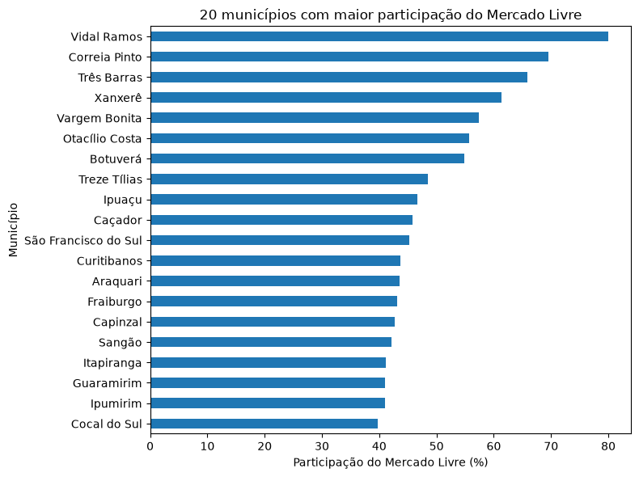

```python
plt.figure(figsize=(8, 6))

participacao["% Livre"].sort_values(ascending=False).head(20).plot(kind="barh")

plt.title("20 municípios com maior participação do Mercado Livre")
plt.xlabel("Participação do Mercado Livre (%)")
plt.ylabel("Município")

plt.gca().invert_yaxis()  # coloca o maior no topo

plt.tight_layout()
plt.show()
```

## Conclusão da Pergunta de Pesquisa 1

A investigação mostrou que a distribuição do consumo de energia elétrica em Santa Catarina apresenta diferentes padrões quando analisada sob perspectivas distintas.

A análise do consumo acumulado evidencia que municípios como Joinville, Florianópolis e Blumenau concentram os maiores volumes de energia consumida ao longo da série histórica, refletindo seu peso econômico e populacional.

Entretanto, ao analisar a participação relativa do Mercado Livre (ACL), observa-se um cenário diferente. Municípios de porte médio, como Vidal Ramos, Correia Pinto, Três Barras e Xanxerê, apresentam as maiores participações percentuais do Ambiente de Contratação Livre, indicando a presença de consumidores de grande porte, geralmente ligados às atividades industriais, agroindustriais ou florestais.

Esses resultados demonstram que o volume absoluto de consumo, por si só, não caracteriza completamente o perfil energético de um município. A participação relativa do Mercado Livre surge como um indicador complementar, capaz de revelar diferenças estruturais entre as economias municipais.

Assim, a primeira pergunta de pesquisa pode ser considerada respondida. Conclui-se que o consumo de energia elétrica em Santa Catarina está concentrado em poucos polos econômicos, mas a estrutura desse consumo varia significativamente entre os municípios quando se observa a participação do Mercado Livre.

A próxima etapa da análise investigará como esse consumo evoluiu ao longo da série histórica, buscando identificar tendências, mudanças de comportamento e possíveis transformações na dinâmica energética do estado.